# Graphical parameters of {graphics} package

Pep Porrà

March 25th, 2017

This document gives examples of use for each parameter of the par function in base {graphics} package. The text that follows after each parameter is the text shown in the par function help.

Before starting with the examples for each parameter, we save first the value of all parameters (those that can be changed) into a variable to be able to reset them to the initial state.

```
op <- par(no.readonly = TRUE)
```

```r
op <- par(no.readonly = TRUE)
```

# Examples for each parameter

## adj

The value of adj determines the way in which text strings are justified in text, mtext and title. A value of 0 produces left-justified text, 0.5 (the default) centered text and 1 right-justified text. (Any value in [0, 1] is allowed, and on most devices values outside that interval will also work.)

Note that the adj argument of text also allows adj = c(x, y) for different adjustment in x- and y- directions. Note that whereas for text it refers to positioning of text about a point, for mtext and title it controls placement within the plot or device region.

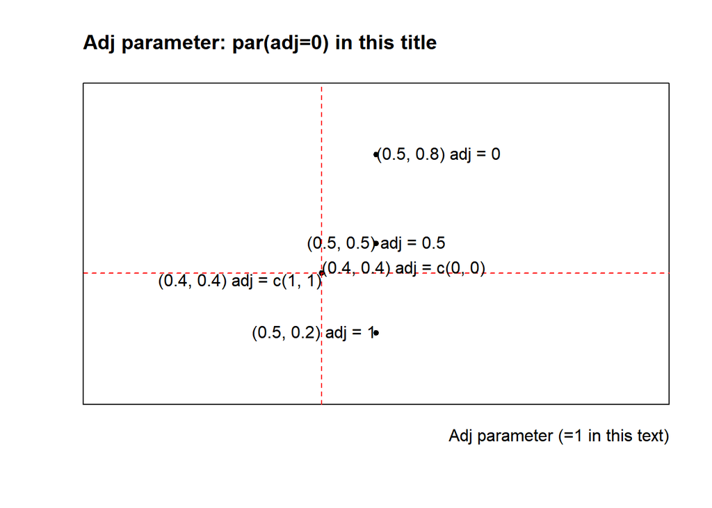

```r
plot(c(0.4, rep(0.5, 3)), c(0.4, 0.2, 0.5, 0.8),
    xlab = "", ylab = "", xaxt = 'n', yaxt = 'n',
    xlim = c(0, 1), ylim = c(0, 1),
    pch = 20)

par(adj = 0)
title("Adj parameter: par(adj=0) in this title")
text(0.5, 0.8, "(0.5, 0.8) adj = 0")
par(adj = 0.5)
text(0.5, 0.5, "(0.5, 0.5) adj = 0.5")
par(adj = 1)
text(0.5, 0.2, "(0.5, 0.2) adj = 1")
abline(h = 0.4, v = 0.4, lty = 2, col = "red")
text(0.4, 0.4, "(0.4, 0.4) adj = c(1, 1)", adj = c(1, 1))
text(0.4, 0.4, "(0.4, 0.4) adj = c(0, 0)", adj = c(0, 0))

mtext("Adj parameter (=1 in this text)", side = 1, line = 1, adj = 1)
```

## ann

If set to FALSE, high-level plotting functions calling plot.default do not annotate the plots they produce with axis titles and overall titles. The default is to do annotation

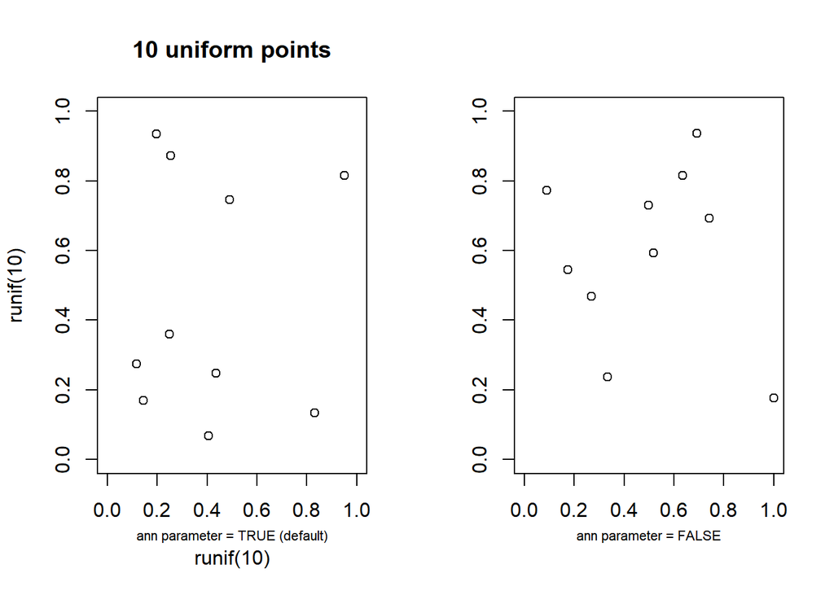

```r
par(mfcol = c(1, 2))
set.seed(1023)
plot(runif(10), runif(10),
     xlim = c(0, 1), ylim = c(0, 1), ann = TRUE, main = "10 uniform points")
mtext("ann parameter = TRUE (default)", side = 1, line = 2, cex = 0.7)
plot(runif(10), runif(10),
     xlim = c(0, 1), ylim = c(0, 1), ann = FALSE, main = "10 uniform points")
mtext("ann parameter = FALSE", side = 1, line = 2, cex = 0.7)
```

## ask

logical. If TRUE (and the R session is interactive) the user is asked for input, before a new figure is drawn. As this applies to the device, it also affects output by packages grid and lattice. It can be set even on non-screen devices but may have no effect there.

This not really a graphics parameter, and its use is deprecated in favor of devAskNewPage.

## bg

The color to be used for the background of the device region. When called from par() it also sets new = FALSE. See section ‘Color Specification’ for suitable values. For many devices the initial value is set from the bg argument of the device, and for the rest it is normally “white”.

Note that some graphics functions such as plot.default and points have an argument of this name with a different meaning.

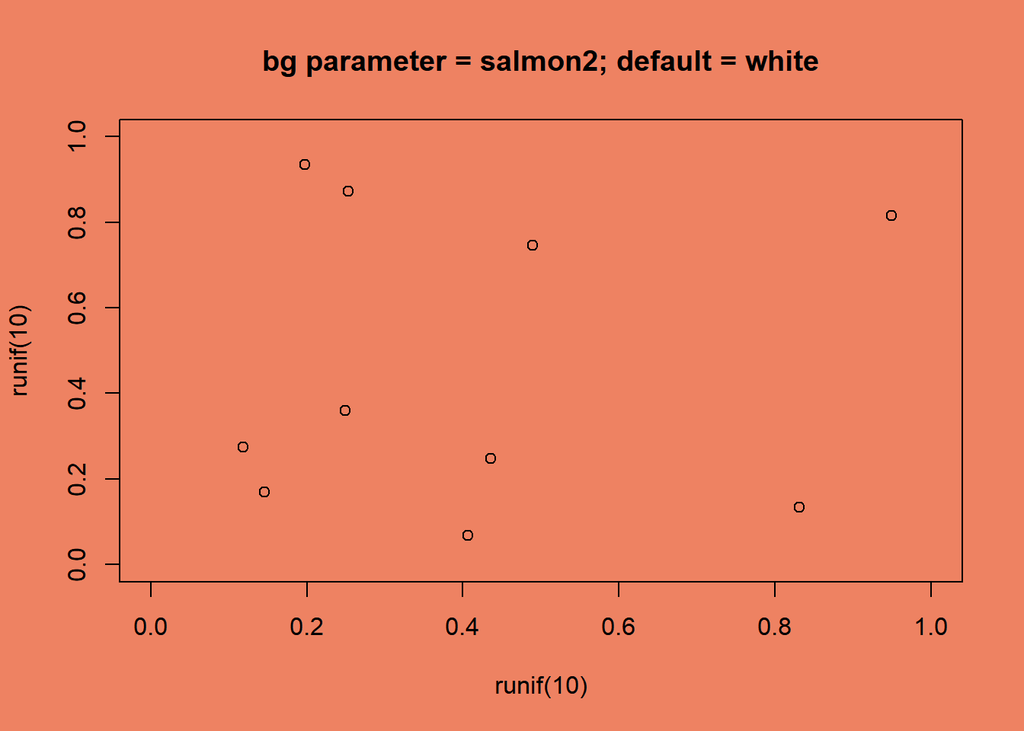

```r
par(bg = 'salmon2')
set.seed(1023)
plot(runif(10), runif(10),
     xlim = c(0, 1), ylim = c(0, 1), main = "bg parameter = salmon2; default = white")
```

## bty

A character string which determined the type of box which is drawn about plots. If bty is one of “o” (the default), “l”, “7”, “c”, “u”, or “]” the resulting box resembles the corresponding upper case letter. A value of “n” suppresses the box.

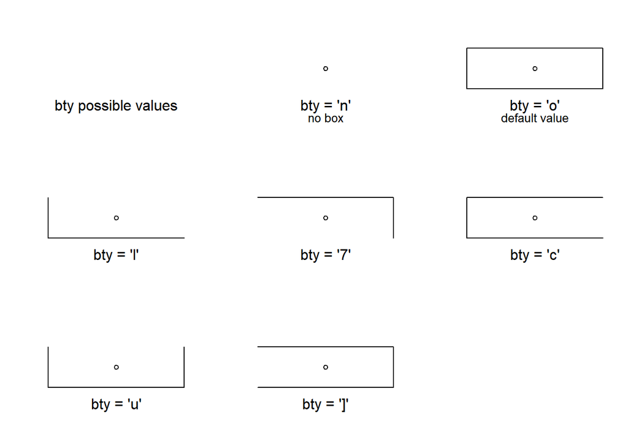

```r
par(mfrow = c(3, 3))
plot(0:1, 0:1, type = 'n', axes = F, xlab = "", ylab = "")
mtext(paste0("bty ", "possible values"), line = 1, side = 1)
plot(0.5, 0.5, bty = 'n', xlab = "", ylab = "", xaxt = 'n', yaxt = 'n')
mtext(paste0("bty = ", "'n'"), line = 1, side = 1)
mtext(paste0("no box"), line = 2, side = 1, cex = 0.8)
plot(0.5, 0.5, bty = 'o', xlab = "", ylab = "", xaxt = 'n', yaxt = 'n')
mtext(paste0("bty = ", "'o'"), line = 1, side = 1)
mtext(paste0("default value"), line = 2, side = 1, cex = 0.8)
plot(0.5, 0.5, bty = 'l', xlab = "", ylab = "", xaxt = 'n', yaxt = 'n')
mtext(paste0("bty = ", "'l'"), line = 1, side = 1)
plot(0.5, 0.5, bty = '7', xlab = "", ylab = "", xaxt = 'n', yaxt = 'n')
mtext(paste0("bty = ", "'7'"), line = 1, side = 1)
plot(0.5, 0.5, bty = 'c', xlab = "", ylab = "", xaxt = 'n', yaxt = 'n')
mtext(paste0("bty = ", "'c'"), line = 1, side = 1)
plot(0.5, 0.5, bty = 'u', xlab = "", ylab = "", xaxt = 'n', yaxt = 'n')
mtext(paste0("bty = ", "'u'"), line = 1, side = 1)
plot(0.5, 0.5, bty = ']', xlab = "", ylab = "", xaxt = 'n', yaxt = 'n')
mtext(paste0("bty = ", "']'"), line = 1, side = 1)
```

## cex

A numerical value giving the amount by which plotting text and symbols should be magnified relative to the default. This starts as 1 when a device is opened, and is reset when the layout is changed, e.g. by setting mfrow.

Note that some graphics functions such as plot.default have an argument of this name which multiplies this graphical parameter, and some functions such as points and text accept a vector of values which are recycled.

### cex.axis

The magnification to be used for axis annotation relative to the current setting of cex.

### cex.lab

The magnification to be used for x and y labels relative to the current setting of cex.

### cex.main

The magnification to be used for main titles relative to the current setting of cex.

### cex.sub

The magnification to be used for sub-titles relative to the current setting of cex.

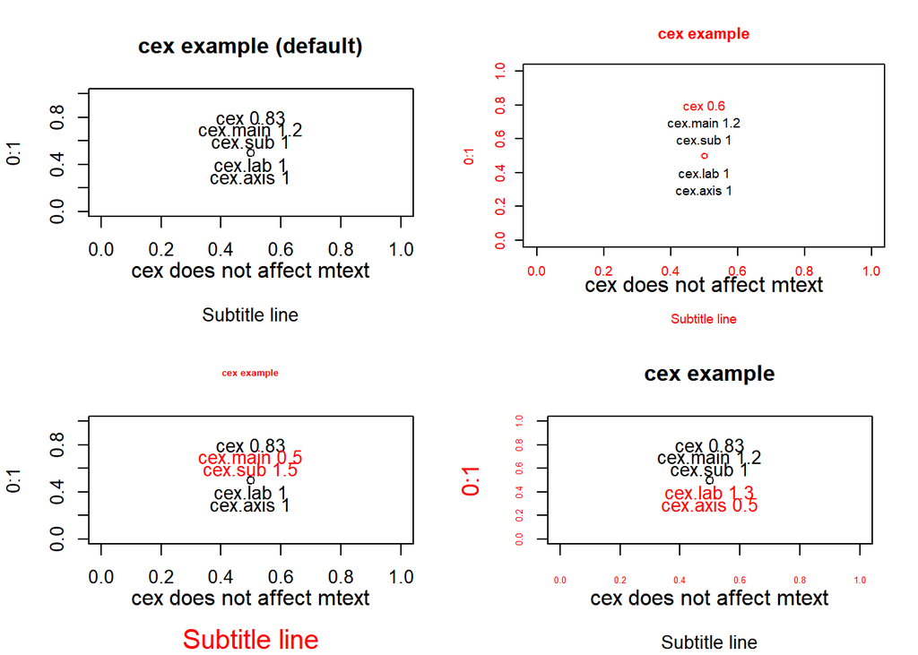

```r
par(mfrow = c(2, 2))

op_cex <- par("cex")
plot(0.5, 0.5
     , xlim = c(0, 1), ylim = c(0, 1)
     , xlab = "", ylab = "0:1"
     , main = "cex example (default)", sub = "Subtitle line")
text(0.5, 0.8, paste("cex", par("cex")))
text(0.5, 0.7, paste("cex.main", par("cex.main")))
text(0.5, 0.6, paste("cex.sub", par("cex.sub")))
text(0.5, 0.4, paste("cex.lab", par("cex.lab")))
text(0.5, 0.3, paste("cex.axis", par("cex.axis")))
mtext("cex does not affect mtext", line = 2, side = 1)

par(cex = 0.6)
plot(0.5, 0.5
     , xlim = c(0, 1), ylim = c(0, 1)
     , xlab = "", ylab = "0:1"
     , main = "cex example", sub = "Subtitle line"
     , col.main = "red", col.sub = "red", col.lab = "red", col.axis = "red"
     , col = "red")
text(0.5, 0.8, paste("cex", par("cex")), col = "red")
text(0.5, 0.7, paste("cex.main", par("cex.main")))
text(0.5, 0.6, paste("cex.sub", par("cex.sub")))
text(0.5, 0.4, paste("cex.lab", par("cex.lab")))
text(0.5, 0.3, paste("cex.axis", par("cex.axis")))
mtext("cex does not affect mtext", line = 2, side = 1)


par(cex = op_cex)
par(cex.main = 0.5)
par(cex.sub = 1.5)
plot(0.5, 0.5
     , xlim = c(0, 1), ylim = c(0, 1)
     , xlab = "", ylab = "0:1"
     , main = "cex example", sub = "Subtitle line"
     , col.main = "red", col.sub = "red")
text(0.5, 0.8, paste("cex", par("cex")))
text(0.5, 0.7, paste("cex.main", par("cex.main")), col = "red")
text(0.5, 0.6, paste("cex.sub", par("cex.sub")), col = "red")
text(0.5, 0.4, paste("cex.lab", par("cex.lab")))
text(0.5, 0.3, paste("cex.axis", par("cex.axis")))
mtext("cex does not affect mtext", line = 2, side = 1)

par(cex.main = op$cex.main, cex.sub = op$cex.sub)
par(cex.axis = 0.5)
par(cex.lab = 1.3)
plot(0.5, 0.5
     , xlim = c(0, 1), ylim = c(0, 1)
     , xlab = "", ylab = "0:1"
     , main = "cex example", sub = "Subtitle line"
     , col.lab = "red", col.axis = "red")

text(0.5, 0.8, paste("cex", par("cex")))
text(0.5, 0.7, paste("cex.main", par("cex.main")))
text(0.5, 0.6, paste("cex.sub", par("cex.sub")))
text(0.5, 0.4, paste("cex.lab", par("cex.lab")), col = "red")
text(0.5, 0.3, paste("cex.axis", par("cex.axis")), col = "red")
mtext("cex does not affect mtext", line = 2, side = 1)
```

## col

A specification for the default plotting color. See section ‘Color Specification’.

Some functions such as lines and text accept a vector of values which are recycled and may be interpreted slightly differently.

### col.axis

The color to be used for axis annotation. Defaults to “black”.

### col.lab

The color to be used for x and y labels. Defaults to “black”.

### col.main

The color to be used for plot main titles. Defaults to “black”.

### col.sub

The color to be used for plot sub-titles. Defaults to “black”.

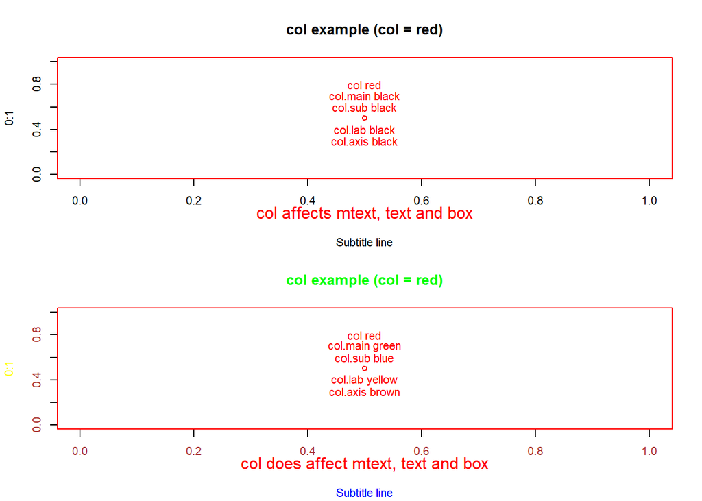

```r
par(mfrow = c(2, 1))
par(cex = 0.7)

op_cex <- par("col")
par(col = "red")
plot(0.5, 0.5
     , xlim = c(0, 1), ylim = c(0, 1)
     , xlab = "", ylab = "0:1"
     , main = "col example (col = red)", sub = "Subtitle line")
text(0.5, 0.8, paste("col", par("col")))
text(0.5, 0.7, paste("col.main", par("col.main")))
text(0.5, 0.6, paste("col.sub", par("col.sub")))
text(0.5, 0.4, paste("col.lab", par("col.lab")))
text(0.5, 0.3, paste("col.axis", par("col.axis")))
mtext("col affects mtext, text and box", line = 2, side = 1)


par(col = "red", col.main = "green", col.sub = "blue", col.lab = "yellow",
    col.axis = "brown")
plot(0.5, 0.5
     , xlim = c(0, 1), ylim = c(0, 1)
     , xlab = "", ylab = "0:1"
     , main = "col example (col = red)", sub = "Subtitle line")
text(0.5, 0.8, paste("col", par("col")))
text(0.5, 0.7, paste("col.main", par("col.main")))
text(0.5, 0.6, paste("col.sub", par("col.sub")))
text(0.5, 0.4, paste("col.lab", par("col.lab")))
text(0.5, 0.3, paste("col.axis", par("col.axis")))
mtext("col does affect mtext, text and box", line = 2, side = 1)
```

## crt

A numerical value specifying (in degrees) how single characters should be rotated. It is unwise to expect values other than multiples of 90 to work. Compare with srt which does string rotation.

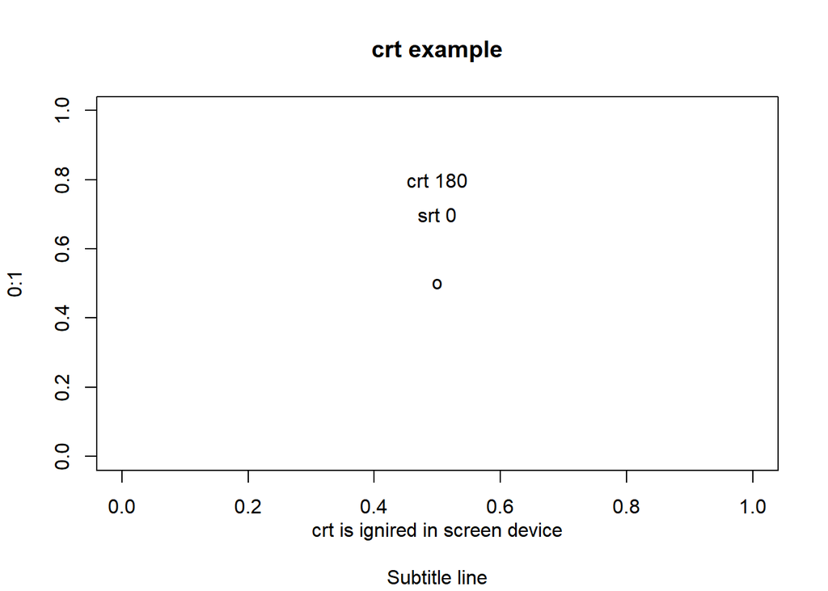

```r
par(crt = 180)
plot(0.5, 0.5
     , xlim = c(0, 1), ylim = c(0, 1)
     , xlab = "", ylab = "0:1"
     , main = "crt example", sub = "Subtitle line"
     , pch = "o")
text(0.5, 0.8, paste("crt", par("crt")))
text(0.5, 0.7, paste("srt", par("srt")))
mtext("crt is ignired in screen device", line = 2, side = 1)
```

## family

The name of a font family for drawing text. The maximum allowed length is 200 bytes. This name gets mapped by each graphics device to a device-specific font description. The default value is “” which means that the default device fonts will be used (and what those are should be listed on the help page for the device). Standard values are “serif”, “sans” and “mono”, and the Hershey font families are also available. (Devices may define others, and some devices will ignore this setting completely. Names starting with “Hershey” are treated specially and should only be used for the built-in Hershey font families.) This can be specified inline for text. Example details: http://www.statmethods.net/advgraphs/parameters.html

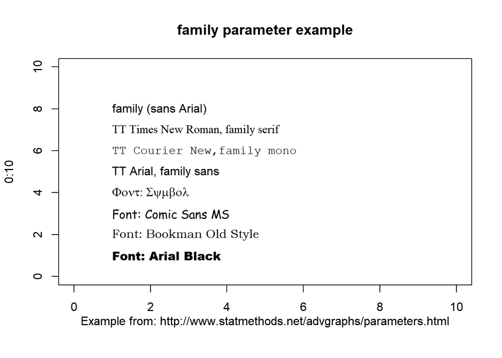

```r
par(cex = 1)
plot(1:10, 1:10, type = 'n'
     , xlim = c(0, 10), ylim = c(0, 10)
     , xlab = "", ylab = "0:10"
     , main = "family parameter example")

windowsFonts(
    A = windowsFont("Arial Black"),
    B = windowsFont("Bookman Old Style"),
    C = windowsFont("Comic Sans MS"),
    D = windowsFont("Symbol"),
    E = windowsFont("Comic Sans MS"))

par(adj = 0)
text(1, 8, paste("family (sans Arial)", par("family")))
par(family = "serif")
text(1, 7, paste("TT Times New Roman, family", par("family")))
par(family = "mono")
text(1, 6, paste("TT Courier New,family", par("family")))
par(family = "sans")
text(1, 5, paste("TT Arial, family", par("family")))

text(1, 1, family = "A", "Font: Arial Black")
text(1, 2, family = "B", "Font: Bookman Old Style")
text(1, 3, family = "C", "Font: Comic Sans MS")
text(1, 4, family = "D", "Font: Symbol")

mtext("Example from: http://www.statmethods.net/advgraphs/parameters.html",
      line = 2, side = 1)
```

## fg

The color to be used for the foreground of plots. This is the default color used for things like axes and boxes around plots. When called from par() this also sets parameter col to the same value. See section ‘Color Specification’. A few devices have an argument to set the initial value, which is otherwise “black”.

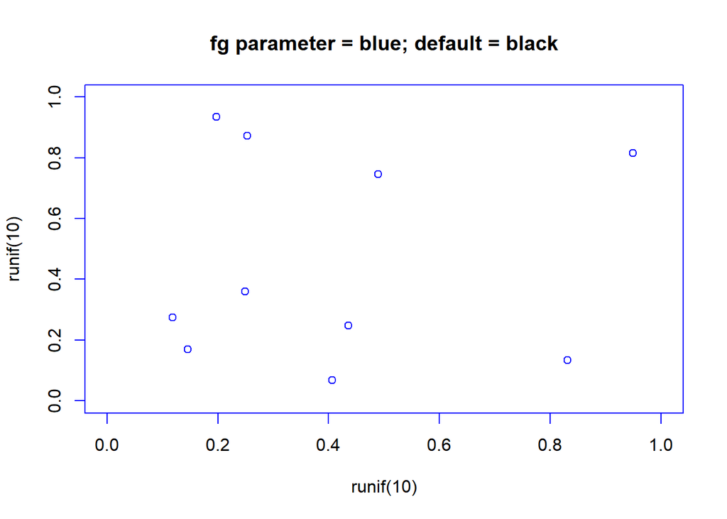

```r
par(fg = 'blue')
set.seed(1023)
plot(runif(10), runif(10),
     xlim = c(0, 1), ylim = c(0, 1), main = "fg parameter = blue; default = black")
```

## fig

A numerical vector of the form c(x1, x2, y1, y2) which gives the (NDC) coordinates of the figure region in the display region of the device. If you set this, unlike S, you start a new plot, so to add to an existing plot use new = TRUE as well.

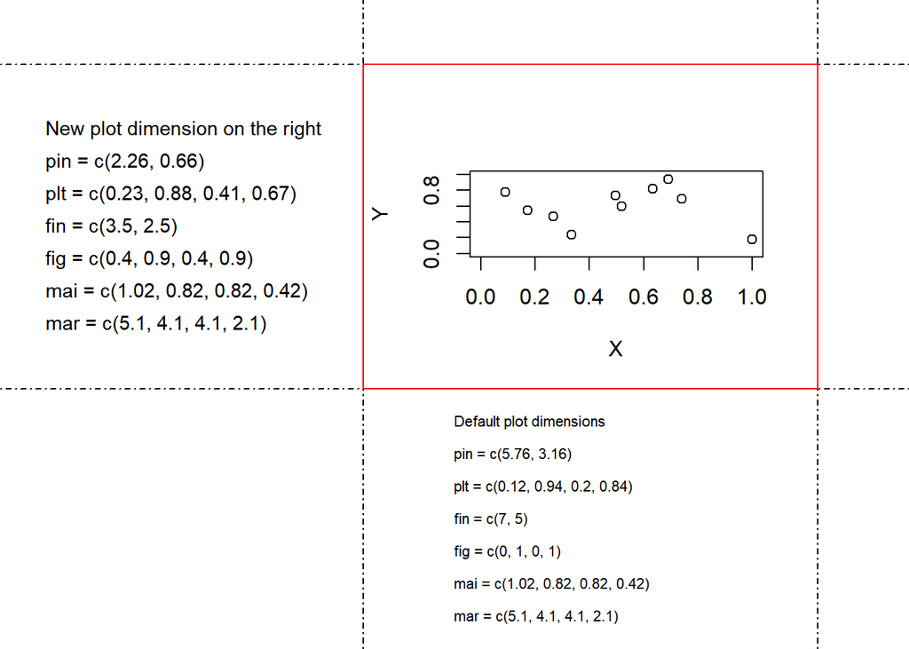

```r
plot_dim <- function(x, y, op, title, ...){
    text(x, y, paste0("mar = c(", paste(op$mar, collapse = ", "), ")"), adj = 0, ...)
    text(x, y + 0.05, paste0("mai = c(", paste(op$mai, collapse = ", "), ")"), adj = 0, ...)
    text(x, y + 0.1, paste0("fig = c(", paste(round(op$fig, 2), collapse = ", "), ")")
        , adj = 0, ...)
    text(x, y + 0.15, paste0("fin = c(", paste(round(op$fin, 2), collapse = ", "), ")")
        , adj = 0, ...)
    text(x, y + 0.2, paste0("plt = c(", paste(round(op$plt, 2), collapse = ", "), ")")
        , adj = 0, ...)
    text(x, y + 0.25, paste0("pin = c(", paste(round(op$pin, 2), collapse = ", "), ")")
        , adj = 0, ...)
    text(x, y + 0.3, title, adj = 0, ...)
}

par(op)

# 1. plot area available when internal margins are 0
par(mai = c(0, 0, 0, 0), xaxs = 'i', yaxs = 'i')
plot.new()
abline(h = c(0.4, 0.9), v = c(0.4, 0.9), lty = 4)
rect(0.4, 0.4, 0.9, 0.9, border = "red")
par(op)

# 2. Plot new fig
newfig <- c(0.4, 0.9, 0.4, 0.9)
par(fig = newfig, new = TRUE)
op_reduced <- par(no.readonly = TRUE)
plot(runif(10), runif(10), typ = 'p',
    xlab = 'X', ylab = 'Y', xlim = c(0, 1), ylim = c(0, 1))
par(op)
par(mai = c(0, 0, 0, 0), xaxs = 'i', yaxs = 'i', new = TRUE)

# 3. Info about dimensions
plot.new()
plot_dim(0.05, 0.5, op_reduced,"New plot dimension on the right", cex = 0.9)
plot_dim(0.5, 0.05, op, "Default plot dimensions", cex = 0.7 )
```

## fin

The figure region dimensions, (width, height), in inches. If you set this, unlike S, you start a new plot.

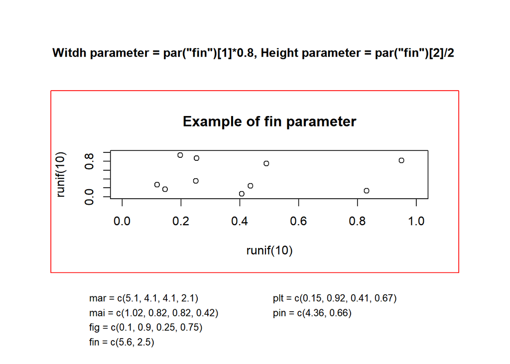

```r
plot_dimensions <- function(x){
    stopifnot(par("mar")[1] >= 4)
    mtext(paste0("mar = c(", paste(round(x[["mar"]], 2), collapse = ", "), ")")
        , side = 1, at = 0, line = 0, cex = 0.8, adj = 0)
    mtext(paste0("mai = c(", paste(round(x[["mai"]], 2), collapse = ", "), ")")
        , side = 1, at = 0, line = 1, cex = 0.8, adj = 0)
    mtext(paste0("fig = c(", paste(round(x[["fig"]], 2), collapse = ", "), ")")
        , side = 1, at = 0, line = 2, cex = 0.8, adj = 0)
    mtext(paste0("fin = c(", paste(round(x[["fin"]], 2), collapse = ", "), ")")
        , side = 1, at = 0, line = 3, cex = 0.8, adj = 0)
    mtext(paste0("plt = c(", paste(round(x[["plt"]], 2), collapse = ", "), ")")
        , side = 1, at = 0.5, line = 0, cex = 0.8, adj = 0)
    mtext(paste0("pin = c(", paste(round(x[["pin"]], 2), collapse = ", "), ")")
        , side = 1, at = 0.5, line = 1, cex = 0.8, adj = 0)
}
par(op)

oldpar <- par(fin = c(op$fin[1]*0.8, op$fin[2] / 2) )
opnew <- par()
set.seed(1023)
plot(runif(10), runif(10), xlim = c(0, 1), ylim = c(0, 1),
    main = "Example of fin parameter")
box("figure", lty = 1, col = "red")
par(oldpar)

# box("plot", lty = "dashed", col = "blue")
plot_dimensions(opnew)
mtext("Witdh parameter = par(\"fin\")[1]*0.8, Height parameter = par(\"fin\")[2]/2"
    , side = 3, at = -0.1, line = 0, font = 2, cex = 1, adj = 0)
```

## font

An integer which specifies which font to use for text. If possible, device drivers arrange so that 1 corresponds to plain text (the default), 2 to bold face, 3 to italic and 4 to bold italic. Also, font 5 is expected to be the symbol font, in Adobe symbol encoding. On some devices font families can be selected by family to choose different sets of 5 fonts.

### font.axis

The font to be used for axis annotation.

### font.lab

The font to be used for x and y labels.

### font.main

The font to be used for plot main titles.

### font.sub

The font to be used for plot sub-titles.

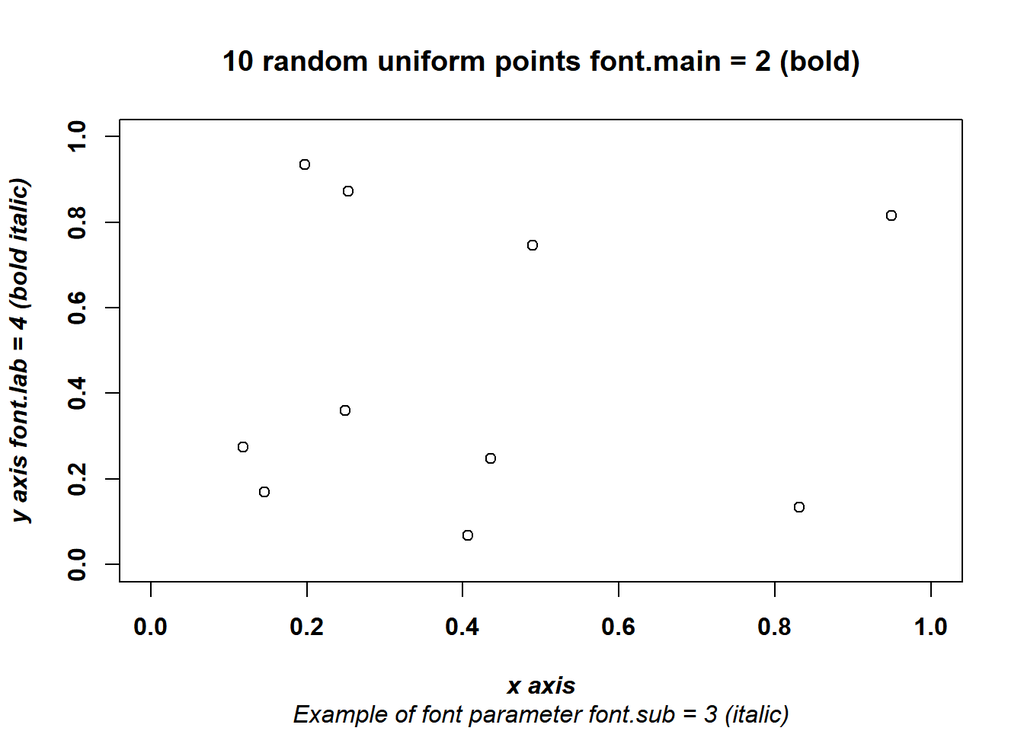

```r
par(op)
par(font.lab = 4, font.sub = 3, font.axis = 2)
set.seed(1023)
plot(runif(10), runif(10)
    , xlim = c(0, 1), ylim = c(0, 1)
    , xlab = "x axis", ylab = "y axis font.lab = 4 (bold italic)"
    , main = "10 random uniform points font.main = 2 (bold)"
    , sub = "Example of font parameter font.sub = 3 (italic)")
```

## lab

A numerical vector of the form c(x, y, len) which modifies the default way that axes are annotated. The values of x and y give the (approximate) number of tickmarks on the x and y axes and len specifies the label length. The default is c(5, 5, 7). Note that this only affects the way the parameters xaxp and yaxp are set when the user coordinate system is set up, and is not consulted when axes are drawn. len is unimplemented in R.

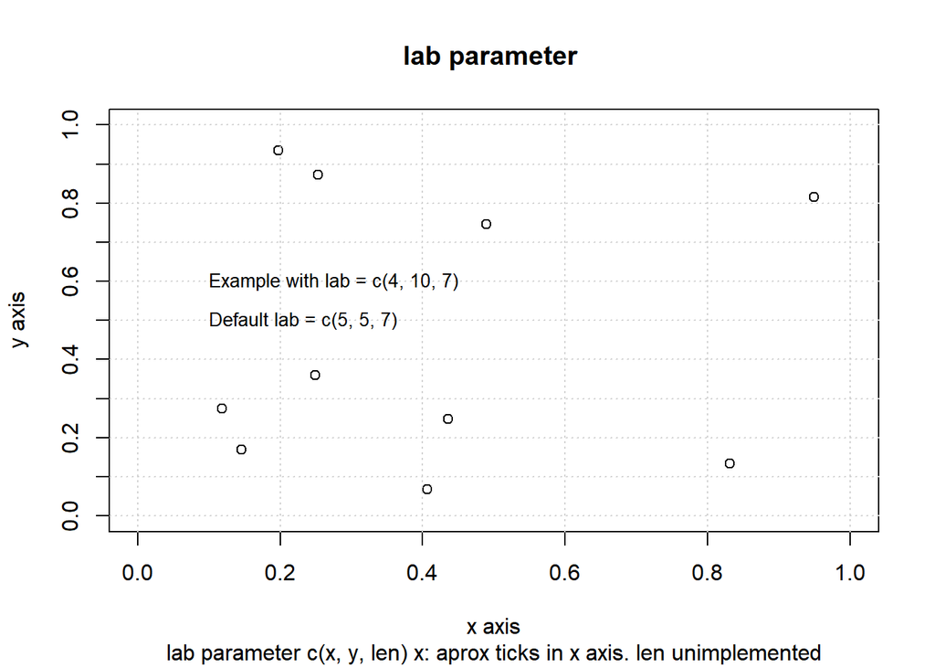

```r
par(op)
par(lab = c(4, 10, 7))
set.seed(1023)
plot(runif(10), runif(10)
    , xlim = c(0, 1), ylim = c(0, 1)
    , xlab = "x axis", ylab = "y axis"
    , main = "lab parameter "
    , sub = "lab parameter c(x, y, len) x: aprox ticks in x axis. len unimplemented")
grid()
text(0.1, 0.6, "Example with lab = c(4, 10, 7)", adj = 0, cex = 0.83)
text(0.1, 0.5, "Default lab = c(5, 5, 7)", adj = 0, cex = 0.83)
```

## las

numeric in {0,1,2,3}; the style of axis labels.

0: always parallel to the axis [default],

1: always horizontal,

2: always perpendicular to the axis,

3: always vertical.

Also supported by mtext. Note that string/character rotation via argument srt to par does not affect the axis labels.

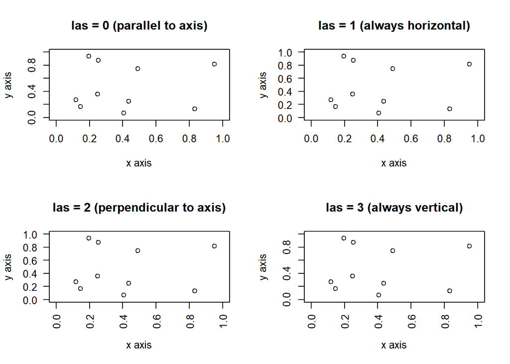

```r
par(op)
par(mfrow = c(2, 2))

set.seed(1023)
plot(runif(10), runif(10)
    , xlim = c(0, 1), ylim = c(0, 1)
    , xlab = "x axis", ylab = "y axis"
    , main = "las = 0 (parallel to axis)")

par(las = 1)
set.seed(1023)
plot(runif(10), runif(10)
    , xlim = c(0, 1), ylim = c(0, 1)
    , xlab = "x axis", ylab = "y axis"
    , main = "las = 1 (always horizontal)")

par(las = 2)
set.seed(1023)
plot(runif(10), runif(10)
    , xlim = c(0, 1), ylim = c(0, 1)
    , xlab = "x axis", ylab = "y axis"
    , main = "las = 2 (perpendicular to axis)")

par(las = 3)
set.seed(1023)
plot(runif(10), runif(10)
    , xlim = c(0, 1), ylim = c(0, 1)
    , xlab = "x axis", ylab = "y axis"
    , main = "las = 3 (always vertical)")
```

## lend

The line end style. This can be specified as an integer or string:

0 and “round” mean rounded line caps [default];

1 and “butt” mean butt line caps;

2 and “square” mean square line caps.

[figure not shown]

```r
par(op)


plot(c(0,1), c(0, 0)
    , type = "l"
    , axes = FALSE
    , xlab=NA, ylab = NA
    , lwd = 11
    , lend = 1
    , main = "Parameter lend (line end) values")


lines(c(0,1), c(0.7, 0.7)
    , type = "l"
    , lwd = 11
    , lend = 0)

lines(c(0,1), c(-0.7, -0.7)
    , type = "l"
    , lwd = 11
    , lend = 2)

text(0.5, 0.9, "lend = 0 (\"round\")")
text(0.5, 0.2, "lend = 1 (\"butt\")")
text(0.5, -0.5, "lend = 0 (\"square\")")

mtext(side = 1
    , text = paste("Based on a document by Melissa Clarkson:",
    "http://www.melissaclarkson.com/resources/R_guides/documents/line_styles_Ver2.pdf", sep = "\n")
    ,line = 2
    ,at = 0
    ,cex = 0.8
    ,col = "blue"
    ,adj = 0)
```

## lheight

The line height multiplier. The height of a line of text (used to vertically space multi-line text) is found by multiplying the character height both by the current character expansion and by the line height multiplier. Default value is 1. Used in text and strheight.

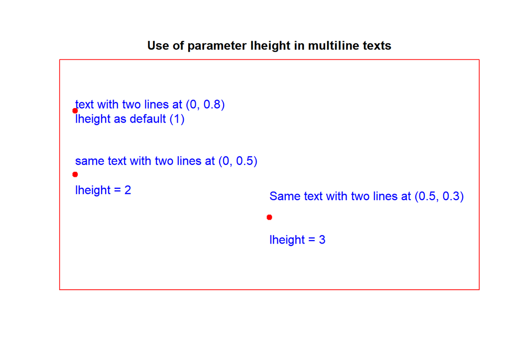

```r
par(op)


plot(c(0, 0, 0.5), c(0.8, 0.5, 0.3)
    , type = "p"
    , axes = FALSE
    , xlab=NA, ylab = NA
    , xlim = c(0, 1), ylim = c(0, 1)
    , lend = 0
    , pch = 19, col = "red")

mtext(side = 3, line = 0.5, at = 0.5, font = 2, text = "Use of parameter lheight in multiline texts")
box("plot", lty = 1, col = "red")

text(0, 0.8
    , paste("text with two lines at (0, 0.8)",
    "lheight as default (1)", sep = "\n")
    ,col = "blue"
    ,adj = 0)

par(lheight = 2)
text(0, 0.5
    , paste("same text with two lines at (0, 0.5)",
    "lheight = 2", sep = "\n")
    ,col = "blue"
    ,adj = 0)

par(lheight = 3)
text(0.5, 0.3
    , paste("Same text with two lines at (0.5, 0.3)",
    "lheight = 3", sep = "\n")
    ,col = "blue"
    ,adj = 0)
```

## ljoin

The line join style. This can be specified as an integer or string:

0 and “round” mean rounded line joins [default];

1 and “mitre” mean mitred line joins;

2 and “bevel” mean bevelled line joins.

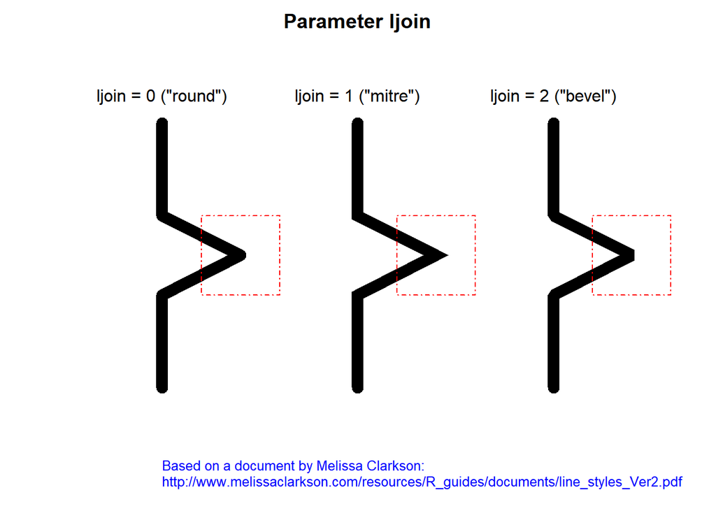

```r
par(op)

x = c(-1, -1, -0.6, -1, -1)
y = c(-1, -0.3, 0, 0.3, 1)

par(lwd = 11, mar = rep(2, 4))
plot(x, y
    , type = "l"
    , axes = FALSE
    , xlab=NA, ylab = NA
    , xlim = c(-1.5, 1.5), ylim = c(-1.5, 1.5)
    , main = "Parameter ljoin")

lines(x + 1, y
    , type = "l"
    , ljoin = 1)

lines(x + 2, y
    , type = "l"
    , ljoin = 2)

text(-1, 1.2, "ljoin = 0 (\"round\")")
text(0, 1.2, "ljoin = 1 (\"mitre\")")
text(1, 1.2, "ljoin = 2 (\"bevel\")")

mtext(side = 1
    , text = paste("Based on a document by Melissa Clarkson:",
    "http://www.melissaclarkson.com/resources/R_guides/documents/line_styles_Ver2.pdf", sep = "\n")
    ,line = 0
    ,at = -1
    ,cex = 0.8
    ,col = "blue"
    ,adj = 0)

par(lwd = 1)
rect(-0.8, -0.3, -0.4, 0.3, lty = "dotdash", border = "red")
rect(0.2, -0.3, 0.6, 0.3, lty = "dotdash", border = "red")
rect(1.2, -0.3, 1.6, 0.3, lty = "dotdash", border = "red")
```

## lmitre

The line mitre limit. This controls when mitred line joins are automatically converted into bevelled line joins. The value must be larger than 1 and the default is 10. Not all devices will honour this setting.

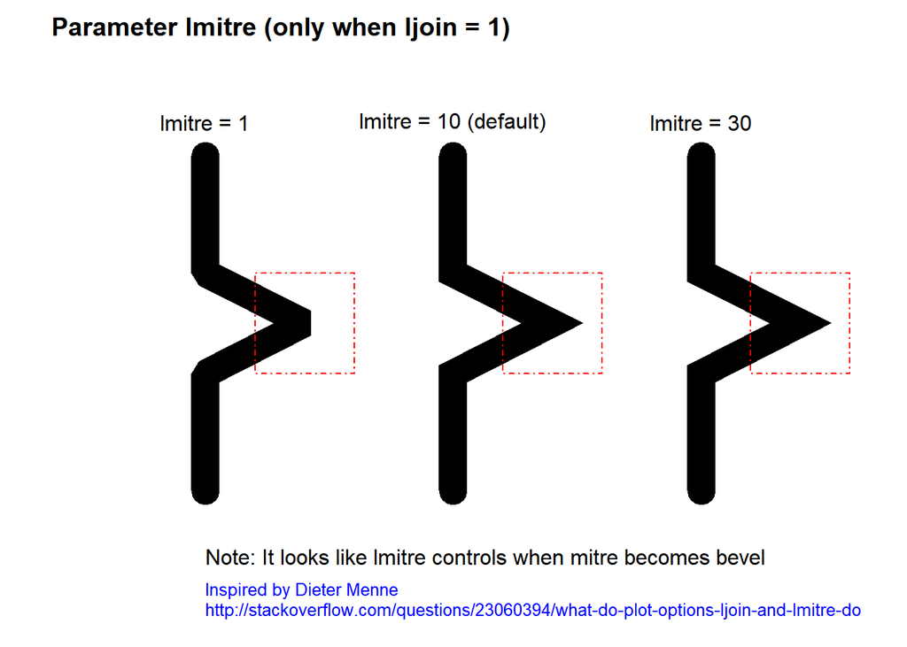

```r
par(op)

x = c(-1, -1, -0.6, -1, -1)
y = c(-1, -0.3, 0, 0.3, 1)

par(lwd = 21, mar = rep(2, 4))
plot(x, y
    , type = "l"
    , axes = FALSE
    , xlab=NA, ylab = NA
    , xlim = c(-1.5, 1.5), ylim = c(-1.5, 1.5)
    , main = "Parameter lmitre (only when ljoin = 1)", adj = 0
    , ljoin = 1
    , lmitre = 1)

lines(x + 1, y
    , type = "l"
    , ljoin = 1)

lines(x + 2, y
    , type = "l"
    , ljoin = 1
    , lmitre = 30)

text(-1, 1.2, "lmitre = 1")
text(0, 1.2, "lmitre = 10 (default)")
text(1, 1.2, "lmitre = 30")
mtext(side = 1
    , text = "Note: It looks like lmitre controls when mitre becomes bevel"
    ,line = -2
    ,at = -1
    ,adj = 0)

mtext(side = 1
    , text = paste("Inspired by Dieter Menne",
    "http://stackoverflow.com/questions/23060394/what-do-plot-options-ljoin-and-lmitre-do", sep = "\n")
    ,line = 0
    ,at = -1
    ,cex = 0.8
    ,col = "blue"
    ,adj = 0)

par(lwd = 1)
rect(-0.8, -0.3, -0.4, 0.3, lty = "dotdash", border = "red")
rect(0.2, -0.3, 0.6, 0.3, lty = "dotdash", border = "red")
rect(1.2, -0.3, 1.6, 0.3, lty = "dotdash", border = "red")
```

## lty

The line type. Line types can either be specified as an integer (0=blank, 1=solid (default), 2=dashed, 3=dotted, 4=dotdash, 5=longdash, 6=twodash) or as one of the character strings “blank”, “solid”, “dashed”, “dotted”, “dotdash”, “longdash”, or “twodash”, where “blank” uses ‘invisible lines’ (i.e., does not draw them).

Alternatively, a string of up to 8 characters (from c(1:9, “A”:“F”)) may be given, giving the length of line segments which are alternatively drawn and skipped. See section ‘Line Type Specification’.

Functions such as lines and segments accept a vector of values which are recycled.

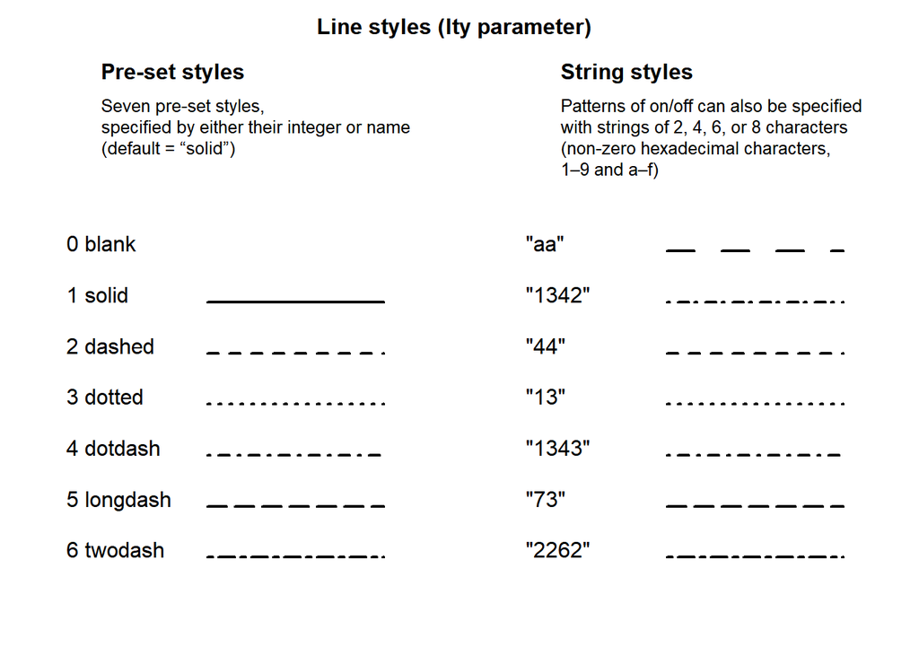

```r
par(op)
par(mar = c(2, 2, 2, 1))
par(mfrow = c(1, 2), lab = c(10, 10, 7))

plot(1, 1
    , type = "n"
    , axes = FALSE
    , xlab = NA, ylab = NA
    , xlim = c(0, 10), ylim = c(0, 10))
# grid(lwd = 2)
lty_string <- c("blank", "solid", "dashed", "dotted", "dotdash", "longdash", "twodash")
for (k in 0:6){
    text(0, 6.5- k, labels = paste(k, lty_string[k + 1]), adj = c(0, 0))
    segments(4, 6.5 - k, 9, 6.5 - k, lty = k, lwd = 2)
}
mtext(side = 3, line = 0.5, at = 11, "Line styles (lty parameter)", font = 2)
text(1, 10, labels = "Pre-set styles", font = 2, adj = 0)
text(1, 9.5, paste("Seven pre-set styles,",
    "specified by either their integer or name", "(default = “solid”)", sep = "\n")
    , cex = 0.8,  adj = c(0, 1))

plot(1, type = "n", axes = FALSE
    , xlab = NA, ylab = NA
    , xlim = c(0, 10), ylim = c(0, 10))
# grid(lwd = 2, col = "red")
text(1, 10, labels = "String styles", font = 2, adj = 0)
text(1, 9.5, paste("Patterns of on/off can also be specified",
    "with strings of 2, 4, 6, or 8 characters",
    "(non-zero hexadecimal characters,", "1–9 and a–f)"
    , sep = "\n")
    , cex = 0.8, adj = c(0, 1))
lty_string <- c("aa", "1342", "44", "13", "1343", "73", "2262")
for (k in 0:6){
    text(0, 6.5- k, labels = paste0("\"", lty_string[k + 1], "\""), adj = c(0, 0))
    segments(4, 6.5 - k, 9, 6.5 - k, lty = lty_string[k + 1], lwd = 2)
}
```

## lwd

The line width, a positive number, defaulting to 1. The interpretation is device-specific, and some devices do not implement line widths less than one. (See the help on the device for details of the interpretation.)

Functions such as lines and segments accept a vector of values which are recycled: in such uses lines corresponding to values NA or NaN are omitted. The interpretation of 0 is device-specific.

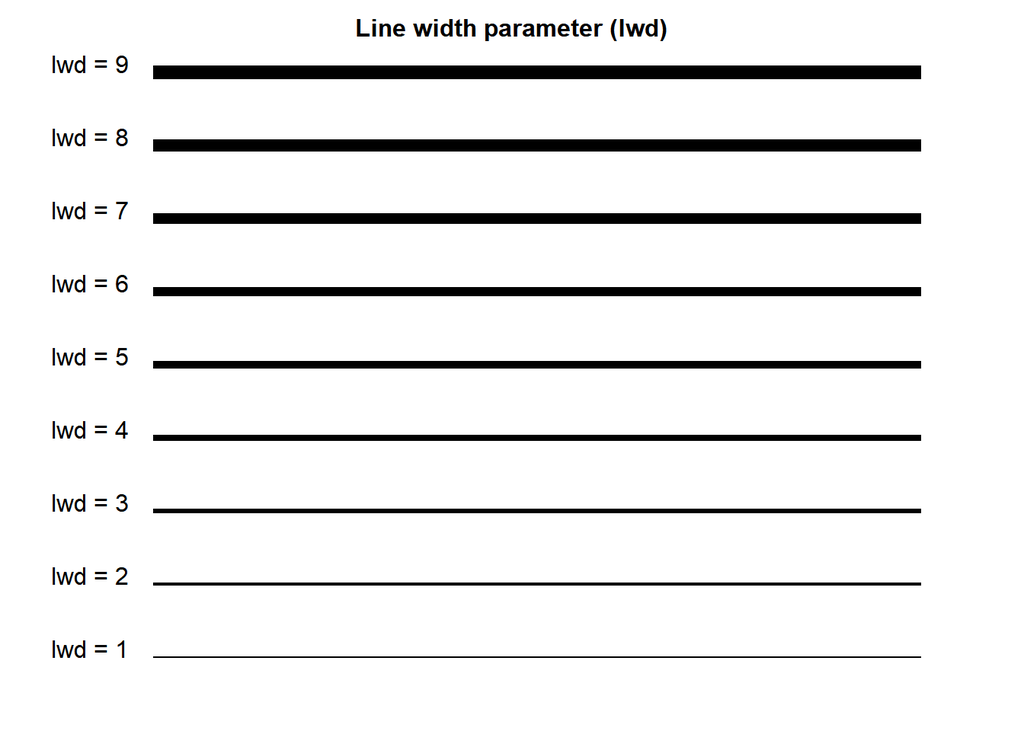

```r
# clean plot area to start drawing
par(mar = rep(0, 4), lend = 1)
plot(1, 1
    , type = 'n', axes = FALSE, ann = FALSE
    , xaxs = 'i', yaxs = 'i'
    , xlim = c(0,10), ylim = c(0,10)
    , lab = c(10, 10, 7))
# grid()
text(5, 9.5, "Line width parameter (lwd)", font = 2, adj = c(0.5, 0))
for (k in 1:9){
    text(0.5, k, labels = paste0("lwd = ", k), adj = c(0, 0))
    segments(1.5, k, 9, k, lwd = k)
}
```

## mai

A numerical vector of the form c(bottom, left, top, right) which gives the margin size specified in inches.

## mar

A numerical vector of the form c(bottom, left, top, right) which gives the number of lines of margin to be specified on the four sides of the plot. The default is c(5, 4, 4, 2) + 0.1.

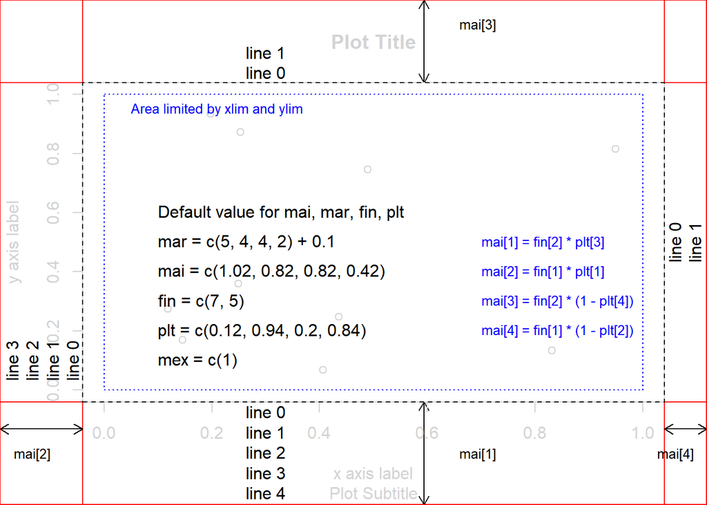

```r
par(op)
# start by plotting plt parameter values
# and fin
par(mar = rep(0, 4))

plot(1, 1
    , type = 'n', axes = FALSE, ann = FALSE
    , xaxs = 'i', yaxs = 'i'
    , xlim = c(0,10), ylim = c(0,10)
    , lab = c(10, 10, 7))
abline(v = op$plt[1:2] * 10, h = op$plt[3:4] * 10, lty = 1, col = "red")
arrows(0, 1.5, op$plt[1]*10, 1.5, code = 3, length = 0.1)
arrows(op$plt[2] * 10, 1.5, 10, 1.5, code = 3, length = 0.1)
arrows(6, 0, 6, op$plt[3]*10, code = 3, length = 0.1)
arrows(6, op$plt[4]*10, 6, 10, code = 3, length = 0.1)
text(0.2, 1, "mai[2]", cex = 0.8, adj = 0)
text(6.5, 1, "mai[1]", cex = 0.8, adj = 0)
text(9.3, 1, "mai[4]", cex = 0.8, adj = 0)
text(6.5, 9.5, "mai[3]", cex = 0.8, adj = 0)

# start by plotting a normal plot with standard parameter but in light colors
plot_color = "lightgray"
par(col.main= plot_color
    , col.lab = plot_color
    , col.sub = plot_color
    , col.axis = plot_color
    , fg = plot_color
    , new = TRUE
    , mar = op$mar)
set.seed(1023)
plot(runif(10), runif(10)
    , type = 'p'
    , xlim = c(0, 1), ylim = c(0, 1)
    , xlab = "x axis label", ylab = "y axis label"
    , main = "Plot Title"
    , sub = "Plot Subtitle")

plot_color = "black"
par(col.main= plot_color
    , col.lab = plot_color
    , col.sub = plot_color
    , col.axis = plot_color
    , fg = plot_color, new = TRUE)
plot(0.5, 0.5, type = 'n', axes = FALSE, xlim = c(0, 1), ylim = c(0, 1),
    xlab = '', ylab = '')
text(0.1, 0.6, "Default value for mai, mar, fin, plt", adj = 0)
text(0.1, 0.5, paste0("mar = c(", paste(par("mar") - 0.1, collapse = ", "), ") + 0.1"), adj = 0)
text(0.1, 0.4, paste0("mai = c(", paste(par("mai"), collapse = ", "), ")"), adj = 0)
text(0.1, 0.3, paste0("fin = c(", paste(round(par("fin"), 2), collapse = ", "), ")"), adj = 0)
text(0.1, 0.2, paste0("plt = c(", paste(round(par("plt"), 2), collapse = ", "), ")"), adj = 0)
text(0.1, 0.1, paste0("mex = c(", paste(round(par("mex"), 2), collapse = ", "), ")"), adj = 0)


text(0.7, 0.5, "mai[1] = fin[2] * plt[3]", cex = 0.8, col ="blue", adj = 0)
text(0.7, 0.4, "mai[2] = fin[1] * plt[1]", cex = 0.8, col ="blue", adj = 0)
text(0.7, 0.3, "mai[3] = fin[2] * (1 - plt[4])", cex = 0.8, col ="blue", adj = 0)
text(0.7, 0.2, "mai[4] = fin[1] * (1 - plt[2])", cex = 0.8, col ="blue", adj = 0)


box("plot", lty = "44")
box("figure", col = "red")
rect(0, 0, 1, 1, lty = 3, border = "blue")
for(k in 0:4){
    mtext(paste0("line ", k), line = k, at = 0.3, side = 1)
}
for(k in 0:3){
    mtext(paste0("line ", k), line = k, at = 0.1, side = 2)
}
for(k in 0:1){
    mtext(paste0("line ", k), line = k, at = 0.3, side = 3)
}
for(k in 0:1){
    mtext(paste0("line ", k), line = k, side = 4)
}
text(0.05, 0.95, "Area limited by xlim and ylim", col = "blue", cex = 0.8, adj = 0)
```

## mex

mex is a character size expansion factor which is used to describe coordinates in the margins of plots. Note that this does not change the font size, rather specifies the size of font (as a multiple of csi) used to convert between mar and mai, and between oma and omi.

This starts as 1 when the device is opened, and is reset when the layout is changed (alongside resetting cex).

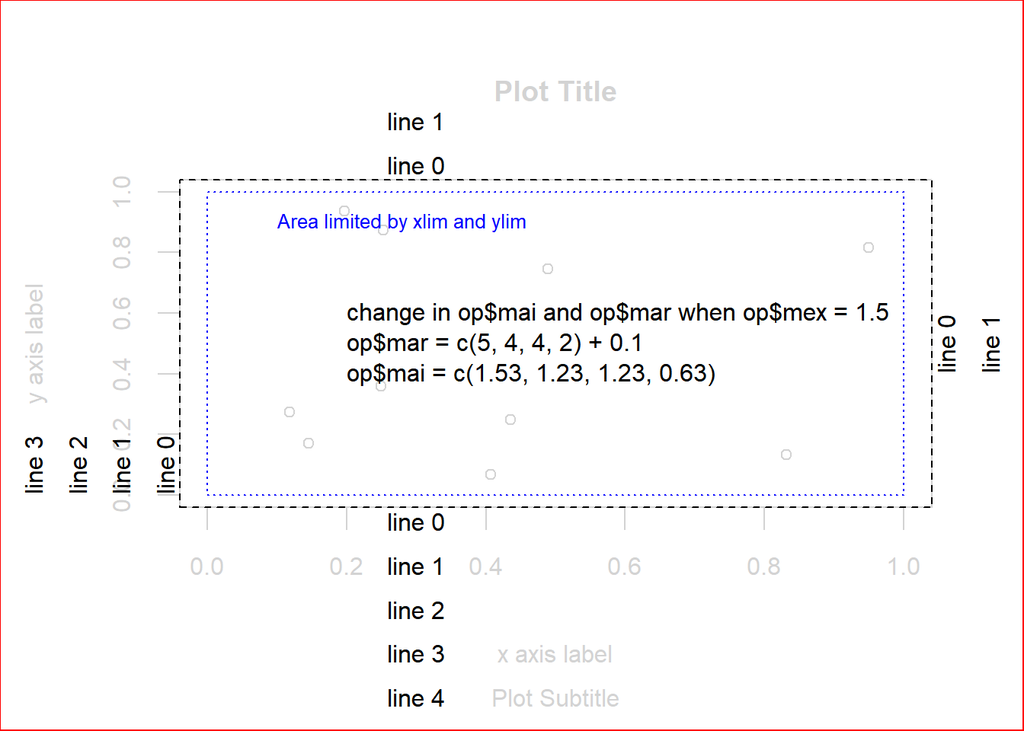

```r
par(op)
par(mex = 1.5)

# start by plotting a normal plot with standard parameter but in light colors
plot_color = "lightgray"
par( col.main= plot_color
    , col.lab = plot_color
    , col.sub = plot_color
    , col.axis = plot_color
    , fg = plot_color)
set.seed(1023)
plot(runif(10), runif(10)
    , type = 'p', xlim = c(0, 1), ylim = c(0, 1),
    xlab = "x axis label", ylab = "y axis label"
    , main = "Plot Title"
    , sub = "Plot Subtitle")
par(op)
par(new = TRUE, par(mex = 1.5))

plot(0.5, 0.5, type = 'n', axes = FALSE, xlim = c(0, 1), ylim = c(0, 1),
    xlab = '', ylab = '')
text(0.2, 0.6, "change in op$mai and op$mar when op$mex = 1.5", adj = 0)
text(0.2, 0.5, paste0("op$mar = c(", paste(par("mar") - 0.1, collapse = ", "), ") + 0.1"), adj = 0)
text(0.2, 0.4, paste0("op$mai = c(", paste(par("mai"), collapse = ", "), ")"), adj = 0)

box("plot", lty = "44")
box("figure", col = "red")
rect(0, 0, 1, 1, lty = 3, border = "blue")
for(k in 0:4){
    mtext(paste0("line ", k), line = k, at = 0.3, side = 1)
}
for(k in 0:3){
    mtext(paste0("line ", k), line = k, at = 0.1, side = 2)
}
for(k in 0:1){
    mtext(paste0("line ", k), line = k, at = 0.3, side = 3)
}
for(k in 0:1){
    mtext(paste0("line ", k), line = k, side = 4)
}
text(0.1, 0.9, "Area limited by xlim and ylim", col = "blue", cex = 0.8, adj = 0)
```

## mfcol, mfrow

A vector of the form c(nr, nc). Subsequent figures will be drawn in an nr-by-nc array on the device by columns (mfcol), or rows (mfrow), respectively.

In a layout with exactly two rows and columns the base value of “cex” is reduced by a factor of 0.83: if there are three or more of either rows or columns, the reduction factor is 0.66.

Setting a layout resets the base value of cex and that of mex to 1.

If either of these is queried it will give the current layout, so querying cannot tell you the order in which the array will be filled.

Consider the alternatives, layout and split.screen.

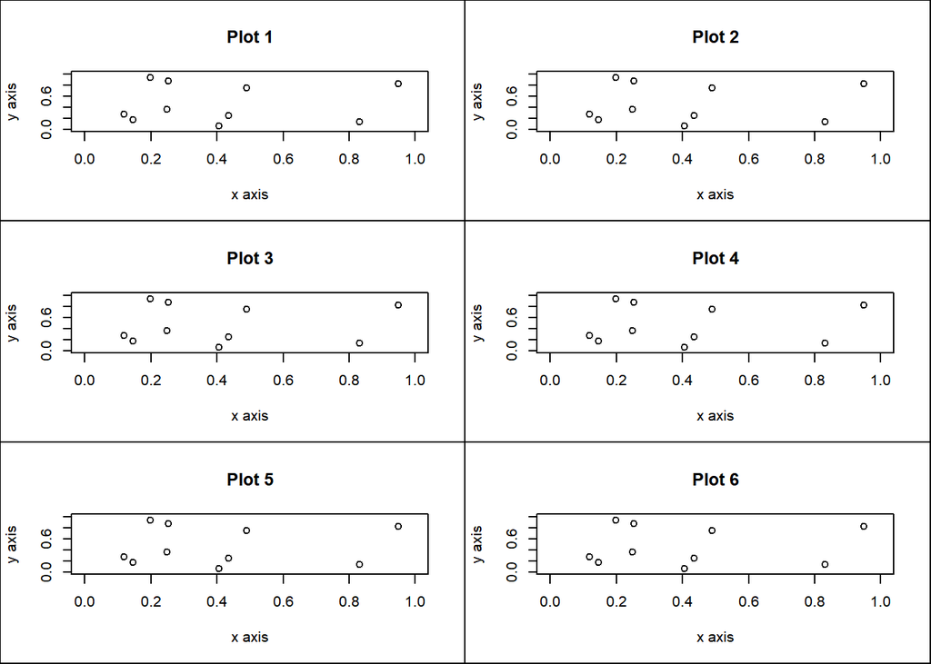

```r
par(op)
par(mfrow = c(3,2))

for(k in 1:6){
set.seed(1023)
plot(runif(10), runif(10)
    , xlim = c(0, 1), ylim = c(0, 1)
    , xlab = "x axis", ylab = "y axis"
    , main = paste("Plot", k))
box("figure")
}
```

## mfg

A numerical vector of the form c(i, j) where i and j indicate which figure in an array of figures is to be drawn next (if setting) or is being drawn (if enquiring). The array must already have been set by mfcol or mfrow.

For compatibility with S, the form c(i, j, nr, nc) is also accepted, when nr and nc should be the current number of rows and number of columns. Mismatches will be ignored, with a warning.

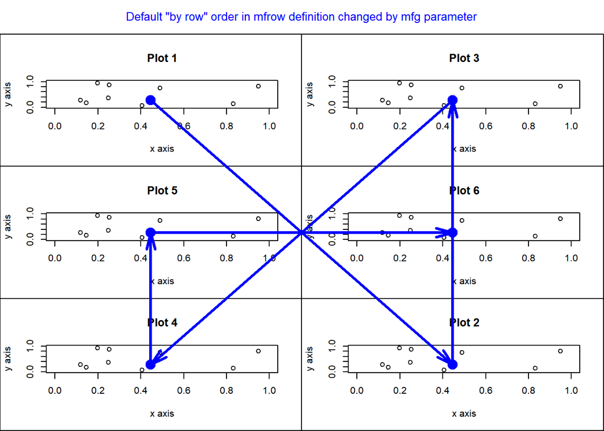

```r
par(op)

par(oma = c(0, 0, 3, 0))
par(mfrow = c(3,2))
plot_order <- c(1, 1, 3, 2, 1, 2, 3, 1, 2, 1, 2, 2)
dim(plot_order) <- c(2, 6)
for (k in 0:5) {
set.seed(1023)
# par(mfg = c(k %% 3, k %/% 3) + 1)
par(mfg = plot_order[, k + 1])
plot(
    runif(10),
    runif(10),
    xlim = c(0, 1),
    ylim = c(0, 1),
    xlab = "x axis",
    ylab = "y axis",
    main = paste("Plot", k + 1)
    )
box("figure")
}

mtext(side = 3, line = 1, cex = 0.8, col = "blue",
    "Default \"by row\" order in mfrow definition changed by mfg parameter", outer = TRUE)

par(new = TRUE, mfrow = c(1,1))
# clean plot area to start drawing
par(mar = rep(0, 4), oma = c(0, 0, 2, 0))
plot(1, 1
    , type = 'n', axes = FALSE, ann = FALSE
    , xaxs = 'i', yaxs = 'i'
    , xlim = c(0,10), ylim = c(0,9)
    , lab = c(3, 8, 7))
#abline(v=c(2.5, 5, 7.5), h = 1.5+ 3 * (0:2), col = "red", lty = 2)
#points(rep(c(2.5, 7.5), 3), rep(1.5+ 3 * (0:2), 2), pch = 19, col = "blue", lwd = 5)
points_indicator <- data.frame( x = c(2.5, 7.5, 7.5, 2.5, 2.5, 7.5),
    y = c(7.5, 1.5, 7.5, 1.5, 4.5, 4.5))
points(points_indicator, pch = 19, col = "blue", lwd = 5)
for (k in 1:5) {
    arrows(
        points_indicator$x[k],
        points_indicator$y[k],
        points_indicator$x[k + 1],
        points_indicator$y[k + 1],
        code = 2,
        col = "blue",
        lwd = 3,
        length = 0.2,
        angle = 15
    )
}
```

## mgp

The margin line (in mex units) for the axis title, axis labels and axis line. Note that mgp[1] affects title whereas mgp[2:3] affect axis. The default is c(3, 1, 0).

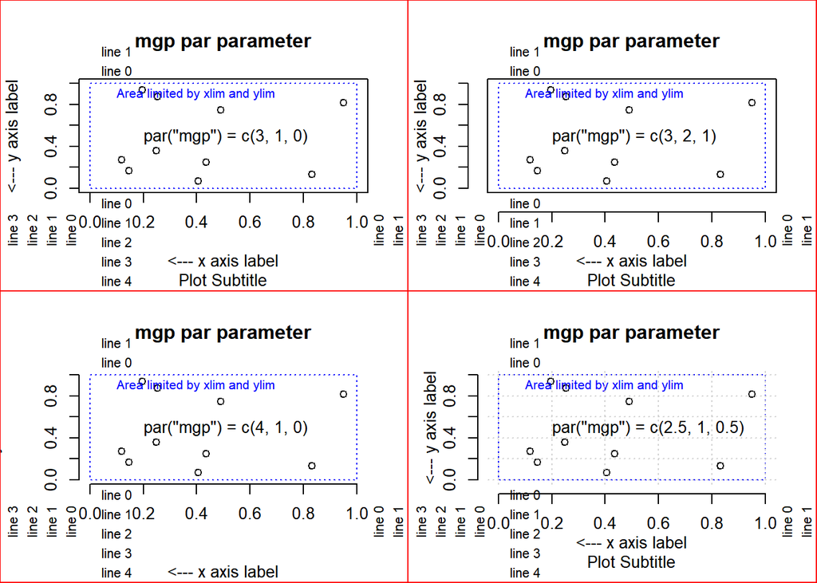

```r
# function to show lines in internal margins
internal_margin <- function() {
    for (k in 0:4) {
        mtext(paste0("line ", k), line = k, at = 0.1, side = 1, cex = 0.7)
    }
    for (k in 0:3) {
        mtext(paste0("line ", k), line = k, at = -0.4, side = 2, cex = 0.7)
    }
    for (k in 0:1) {
        mtext(paste0("line ", k), line = k, at = 0.1, side = 3, cex = 0.7)
    }
    for (k in 0:1) {
        mtext(paste0("line ", k), line = k, at = -0.4, side = 4, cex = 0.7)
    }
}

basic_plot <- function(){
    plot_color = "black"
    par(col.main = plot_color
        , col.lab = plot_color
        , col.sub = plot_color
        , col.axis = plot_color
        , fg = plot_color)
    set.seed(1023)
    plot(runif(10), runif(10)
        , type = 'p', xlim = c(0, 1), ylim = c(0, 1),
        xlab = "<--- x axis label", ylab = "<--- y axis label"
        , main = "mgp par parameter"
        , sub = "Plot Subtitle")

    par(new = TRUE)
    plot(0.5, 0.5, type = 'n', axes = FALSE, xlim = c(0, 1), ylim = c(0, 1),
        xlab = '', ylab = '')
    text(0.2, 0.5, paste0("par(\"mgp\") = c(", paste(par("mgp"), collapse = ", "), ")"), adj = 0)

    box("plot", lty = "44")
    box("figure", col = "red")
    rect(0, 0, 1, 1, lty = 3, border = "blue")

    text(0.1, 0.9, "Area limited by xlim and ylim", col = "blue", cex = 0.8, adj = 0)
}

# Different configurations for mpg
par(op)
par(mfrow = c(2,2))

# plo1 1
basic_plot()
internal_margin()

# plot 2
par(mgp = c(3, 2, 1))
basic_plot()
internal_margin()

# plot 3
par(mgp = c(4, 1, 0), bty = 'n')
basic_plot()
internal_margin()

# plot 4
par(mgp = c(2.5, 1, 0.5), bty = 'n')
basic_plot()
internal_margin()
grid()
```

## mkh

The height in inches of symbols to be drawn when the value of pch is an integer. Completely ignored in R.

## new

logical, defaulting to FALSE. If set to TRUE, the next high-level plotting command (actually plot.new) should not clean the frame before drawing as if it were on a new device. It is an error (ignored with a warning) to try to use new = TRUE on a device that does not currently contain a high-level plot.

## oma

A vector of the form c(bottom, left, top, right) giving the size of the outer margins in lines of text.

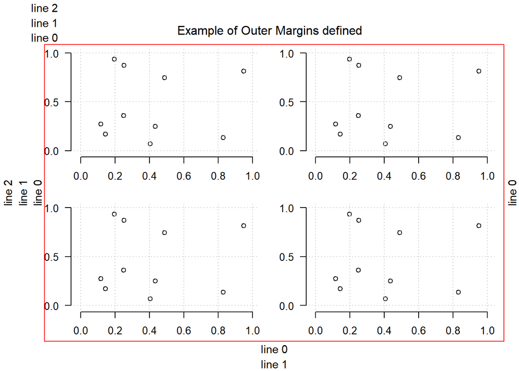

```r
outer_margin <- function() {
    par(las = 0)
    for(k in 0:1){
        mtext(paste0("line ", k), line = k , side = 1, cex = 0.9, outer = TRUE)
    }
    for(k in 0:2){
        mtext(paste0("line ", k), line = k, side = 2, cex = 0.9, outer = TRUE)
    }
    for(k in 0:2){
        mtext(paste0("line ", k), line = k, at = 0, side = 3, cex = 0.9, outer = TRUE)
    }
    for(k in 0:0){
        mtext(paste0("line ", k), line = k, side = 4, cex = 0.9, outer = TRUE)
    }
}

par(op)
par(oma = c(2, 3, 3, 1))
par(mfrow = c(2,2), mar = c(3, 3, 1, 1), mgp = c(3, 1, 0.2), bty = 'n', las = 1,
    lab = c(4, 3, 7))
for(k in 0:3){
    set.seed(1023)
    plot(runif(10), runif(10)
        , xlim = c(0, 1), ylim = c(0, 1)
        , xlab = "x axis", ylab = "y axis"
        )
    grid()
    # box("figure")
}
mtext(text = "Example of Outer Margins defined ", line = 0, side = 3, outer = TRUE)
par(mfrow = c(1, 1), new = TRUE)
box("figure", col = "red")
outer_margin()
```

## omd

A vector of the form c(x1, x2, y1, y2) giving the region inside outer margins in NDC (= normalized device coordinates), i.e., as a fraction (in [0, 1]) of the device region.

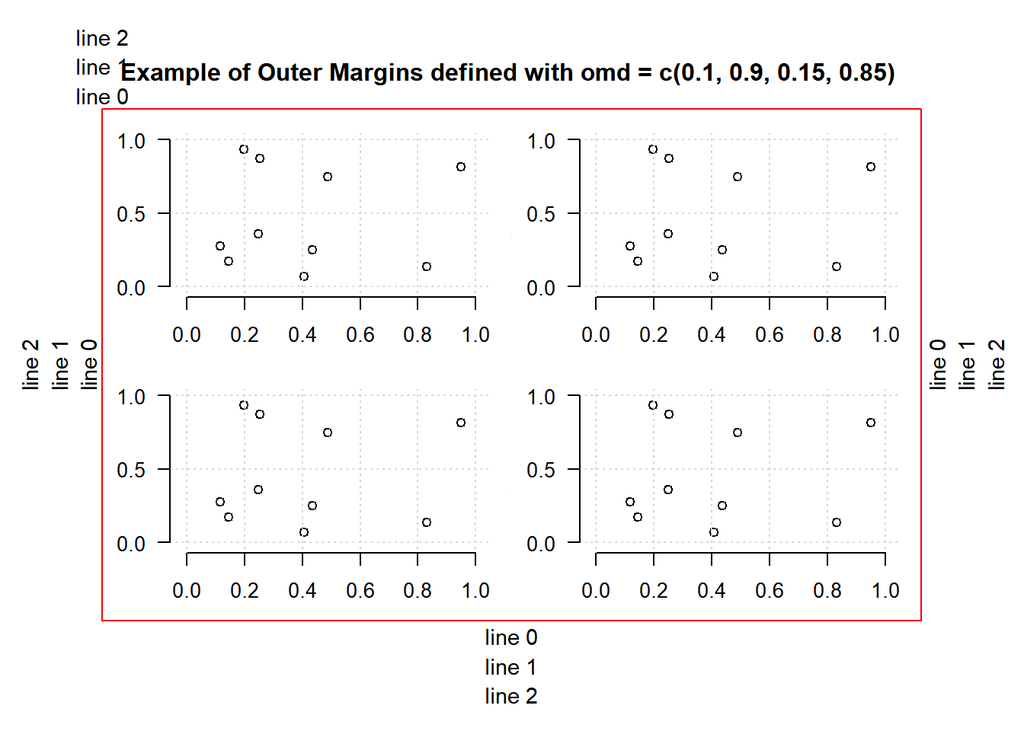

```r
outer_margin <- function() {
    par(las = 0)
    for(k in 0:2){
        mtext(paste0("line ", k), line = k , side = 1, cex = 0.9, outer = TRUE)
    }
    for(k in 0:2){
        mtext(paste0("line ", k), line = k, side = 2, cex = 0.9, outer = TRUE)
    }
    for(k in 0:2){
        mtext(paste0("line ", k), line = k, at = 0, side = 3, cex = 0.9, outer = TRUE)
    }
    for(k in 0:2){
        mtext(paste0("line ", k), line = k, side = 4, cex = 0.9, outer = TRUE)
    }
}

par(op)
par(omd = c(0.1, 0.9, 0.15, 0.85))
par(mfrow = c(2,2), mar = c(3, 3, 1, 1), mgp = c(3, 1, 0.2), bty = 'n', las = 1,
    lab = c(4, 3, 7))
for(k in 0:3){
    set.seed(1023)
    plot(runif(10), runif(10)
        , xlim = c(0, 1), ylim = c(0, 1)
        , xlab = "x axis", ylab = "y axis"
        )
    grid()
    # box("figure")
}
mtext(text = "Example of Outer Margins defined with omd = c(0.1, 0.9, 0.15, 0.85) "
    , line = 1, side = 3, font = 2, outer = TRUE)
par(mfrow = c(1, 1), new = TRUE)
box("figure", col = "red")
outer_margin()
```

## omi

A vector of the form c(bottom, left, top, right) giving the size of the outer margins in inches.

## page

R.O.; A boolean value indicating whether the next call to plot.new is going to start a new page. This value may be FALSE if there are multiple figures on the page.

## pch

Either an integer specifying a symbol or a single character to be used as the default in plotting points. See points for possible values and their interpretation. Note that only integers and single-character strings can be set as a graphics parameter (and not NA nor NULL).

Some functions such as points accept a vector of values which are recycled.

Plot design was copied from [Quick-R](http://www.statmethods.net/index.html)

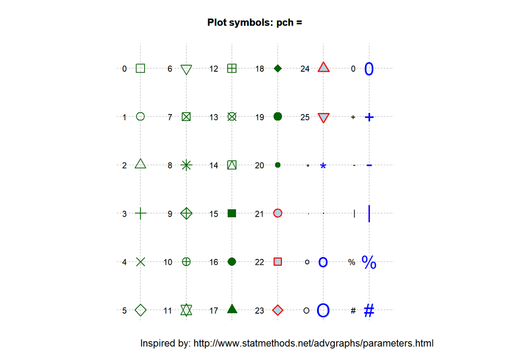

```r
x <- (0:35) %/% 6
y <- 5 - (0:35) %% 6
par(pty = 's', mar = c(3, 4, 3, 4), lab = c(5, 6, 7))
plot(x, y, typ = 'n', pch = 0:25,
    axes = FALSE,
    xlab = NA, ylab = NA,
    xlim = c(-0.3, 5.3), ylim = c(0, 5.3))
abline( h = 0:5, v = 0:5, col = 'lightgray', lty = "22", lwd = 1)
par(new = TRUE, col = 'darkgreen')

# First 15 0:14
index_symbol <- 1:21
plot(x[index_symbol], y[index_symbol], typ = 'p',
    pch = index_symbol - 1,
    axes = FALSE,
    xlab = NA, ylab = NA, cex = 1.5,
    main = "Plot symbols: pch =", cex.main = 0.8,
    xlim = c(-0.3, 5.3), ylim = c(0, 5.3))
text(x[index_symbol] - 0.3, y[index_symbol], index_symbol - 1,
    adj = 1, col = 'black', cex = 0.7)
# From 15 to 25
index_symbol <- 22:26
par(new = TRUE, col = 'darkgreen')
plot(x[index_symbol], y[index_symbol], typ = 'p',
    pch = index_symbol - 1,
    axes = FALSE,
    xlab = NA, ylab = NA, cex = 1.5,
    main = "Plot symbols: pch =", cex.main = 0.8,
    xlim = c(-0.3, 5.3), ylim = c(0, 5.3), bg = "lightblue",
    col = "red", lwd = 1.5)
text(x[index_symbol] - 0.3, y[index_symbol], index_symbol - 1,
    adj = 1, col = 'black', cex = 0.7)

# From 26 to 35: symbols
symbols <- c("*", ".", "o", "O", "0", "+", "-", "|", "%", "#")
index_symbol <- 27:36
par(new = TRUE, col = 'darkgreen')
plot(x[index_symbol], y[index_symbol], typ = 'p',
    pch = symbols,
    axes = FALSE,
    xlab = NA, ylab = NA, cex = 1.5,
    main = "Plot symbols: pch =", cex.main = 0.8,
    xlim = c(-0.3, 5.3), ylim = c(0, 5.3), col = "blue")
text(x[index_symbol] - 0.3, y[index_symbol], symbols,
    adj = 1, col = 'black', cex = 0.7)
mtext("Inspired by: http://www.statmethods.net/advgraphs/parameters.html"
    , side = 1, line = 1, col = "black", adj = 0, at = 0, cex = 0.8)
```

## pin

The current plot dimensions, (width, height), in inches.

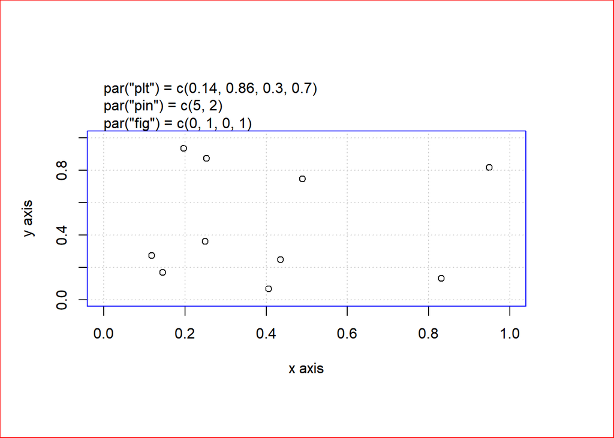

```r
par(op)
par(pin = c(5, 2))
set.seed(1023)
plot(runif(10), runif(10)
    , xlim = c(0, 1), ylim = c(0, 1)
    , xlab = "x axis", ylab = "y axis"
    )
grid()
box("inner", col = "green")
box("plot", col = "blue")
box("figure", col = "red")
mtext(side = 3, line = 1, at = 0, adj = 0, paste0("par(\"pin\") = c(", paste(par("pin"), collapse = ", "), ")"))
mtext(side = 3, line = 2, at = 0, adj = 0, paste0("par(\"plt\") = c(",
    paste(round(par("plt"), 2), collapse = ", "), ")"))
mtext(side = 3, line = 0, at = 0, adj = 0, paste0("par(\"fig\") = c(",
    paste(round(par("fig"), 2), collapse = ", "), ")"))
```

## plt

A vector of the form c(x1, x2, y1, y2) giving the coordinates of the plot region as fractions of the current figure region.

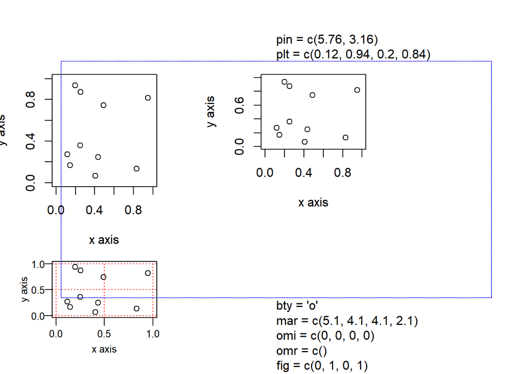

```r
par(op)
plot(0:1, 0:1, typ = 'n', axes = FALSE, xlab = "", ylab = "")
mtext(paste0("bty = ", "'o'"), line = 0, side = 1, at=0.5, adj = 0)
mtext(paste0("mar = c(", paste(op$mar, collapse = ", "), ")"), line = 1, side = 1, at=0.5, adj = 0)
mtext(paste0("omi = c(", paste(op$omi, collapse = ", "), ")"), line = 2, side = 1, at=0.5, adj = 0)
mtext(paste0("omr = c(", paste(op$omr, collapse = ", "), ")"), line = 3, side = 1, at=0.5, adj = 0)
mtext(paste0("fig = c(", paste(op$fig, collapse = ", "), ")"), line = 4, side = 1, at=0.5, adj = 0)
mtext(paste0("plt = c(", paste(round(op$plt, 2), collapse = ", "), ")"), line = 0, side = 3, at=0.5, adj = 0)
mtext(paste0("pin = c(", paste(round(op$pin, 2), collapse = ", "), ")"), line = 1, side = 3, at=0.5, adj = 0)
box(lty = '1111', col = 'blue' )
# abline(v = c(seq(0, 1, 0.1)), h = c(seq(0, 1, 0.1)), lty = 2)

par(plt = c(0.1, 0.3, 0.5, 0.8), new = TRUE)
set.seed(1023)
plot(runif(10), runif(10)
    , xlim = c(0, 1), ylim = c(0, 1)
    , xlab = "x axis", ylab = "y axis"
    )
set.seed(1023)
par(plt = c(0.5, 0.7, 0.6, 0.8), new = TRUE)
plot(runif(10), runif(10)
    , xlim = c(0, 1), ylim = c(0, 1)
    , xlab = "x axis", ylab = "y axis"
    )
set.seed(1023)
par(plt = c(0.1, 0.3, 0.15, 0.3), new = TRUE)
# box(lty = '1111', col = 'blue' )
plot(runif(10), runif(10)
    , xlim = c(0, 1), ylim = c(0, 1)
    , las = 1, mgp = c(1.5, 0.5, 0), cex.lab = 0.8, cex.axis = 0.8
    , lab = c(3, 3, 7)
    , xlab = "x axis", ylab = "y axis"
    )
grid(col = "red")
```

## ps

integer; the point size of text (but not symbols). Unlike the pointsize argument of most devices, this does not change the relationship between mar and mai (nor oma and omi).

What is meant by ‘point size’ is device-specific, but most devices mean a multiple of 1bp, that is 1/72 of an inch.

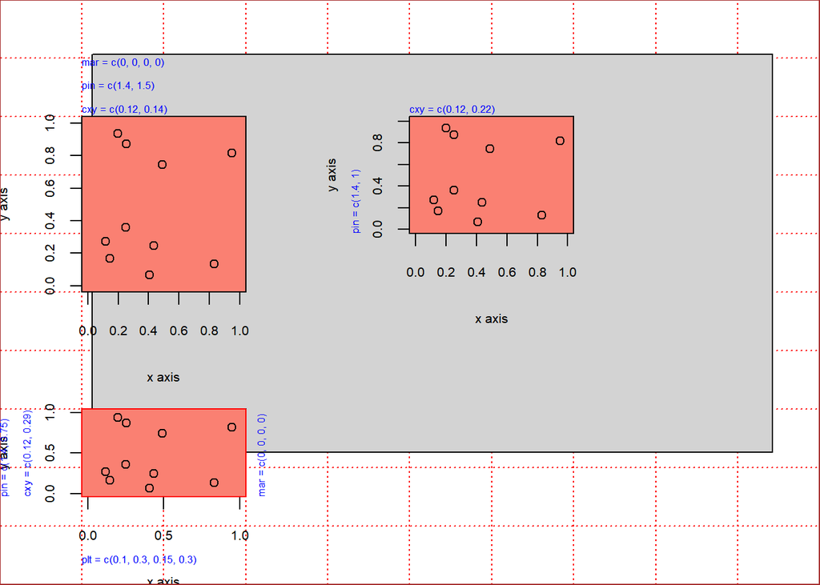

```r
text_info <- function(){
    mtext(paste0("ps = ", "8, (default = 12)"), line = 0, side = 1, at=0.5, adj = 0)
    mtext(paste0("mar = c(", paste(par("mar"), collapse = ", "), ")")
        , line = 1, side = 1, at=0.5, adj = 0)
    mtext(paste0("omi = c(", paste(par("omi"), collapse = ", "), ")")
        , line = 2, side = 1, at=0.5, adj = 0)
    mtext(paste0("mai = c(", paste(par("mai"), collapse = ", "), ")")
        , line = 3, side = 1, at=0.5, adj = 0)
    mtext(paste0("fig = c(", paste(par("fig"), collapse = ", "), ")")
        , line = 4, side = 1, at=0.5, adj = 0)
    mtext(paste0("plt = c(", paste(round(par("plt"), 2), collapse = ", "), ")")
        , line = 0, side = 3, at=0.5, adj = 0)
    mtext(paste0("pin = c(", paste(round(par("pin"), 2), collapse = ", "), ")")
        , line = 1, side = 3, at=0.5, adj = 0)
}
par(op)
oldpar <- par(mar = rep(0, 4))
plot(1, 1
    , type = 'n', axes = FALSE, ann = FALSE
    , xaxs = 'i', yaxs = 'i'
    , xlim = c(0,10), ylim = c(0,10)
    , lab = c(10, 10, 7))
grid(col = "red")
rect(1.124572, 2.266667, 9.424000, 9.066666, col = "lightgray")
rect(1, 5, 3, 8, col = "salmon")
rect(5, 6, 7, 8, col = "salmon")
rect(1, 1.5, 3, 3, col = "salmon")


par(oldpar, new = TRUE)
oldpar <- par(ps = 8)
plot(0:1, 0:1, typ = 'n', axes = TRUE, xlab = "", ylab = "")
text_info()
# abline(v = c(seq(0, 1, 0.1)), h = c(seq(0, 1, 0.1)), lty = 2)

par(plt = c(0.1, 0.3, 0.5, 0.8), new = TRUE)
set.seed(1023)
plot(runif(10), runif(10)
    , xlim = c(0, 1), ylim = c(0, 1)
    , xlab = "x axis", ylab = "y axis"
    )
mtext(side = 3, line = 0
    , paste0("cxy = c(", paste(round(par("cxy"), 2), collapse = ", "), ")")
    , cex = 0.8, col = "blue", adj = 0)
mtext(side = 3, line = 1
    , paste0("pin = c(", paste(round(par("pin"), 2), collapse = ", "), ")")
    , cex = 0.8, col = "blue", adj = 0)
mtext(side = 3, line = 2
    , paste0("mar = c(", paste(round(par("mar"), 2), collapse = ", "), ")")
    , cex = 0.8, col = "blue", adj = 0)


set.seed(1023)
par( mar = rep(0, 4), plt = c(0.5, 0.7, 0.6, 0.8), new = TRUE)
plot(runif(10), runif(10)
    , xlim = c(0, 1), ylim = c(0, 1)
    , xlab = "x axis", ylab = "y axis"
    )
box("figure", lty = '1441', col = 'blue' )
mtext(side = 2, line = 2
    , paste0("pin = c(", paste(round(par("pin"), 2), collapse = ", "), ")")
    , cex = 0.8, col = "blue", adj = 0)
mtext(side = 3, line = 0
    , paste0("cxy = c(", paste(round(par("cxy"), 2), collapse = ", "), ")")
    , cex = 0.8, col = "blue", adj = 0)


set.seed(1023)
par(plt = c(0.1, 0.3, 0.15, 0.3), new = TRUE)
# box(lty = '1111', col = 'blue' )
plot(runif(10), runif(10)
    , xlim = c(0, 1), ylim = c(0, 1)
    # , las = 1, mgp = c(1.5, 0.5, 0), cex.lab = 0.8, cex.axis = 0.8
    , lab = c(3, 3, 7)
    , xlab = "x axis", ylab = "y axis"
    )
box("inner", lty = 1, col = 'blue' )
box("figure", lty = 1, col = 'green' )
box("plot", lty = 1, col = 'red' )
box("outer", lty = 1, col = 'brown' )
mtext(side = 1, line = 2
    , paste0("plt = c(", paste(round(par("plt"), 2), collapse = ", "), ")")
    , cex = 0.8, col = "blue", adj = 0)
mtext(side = 2, line = 2
    , paste0("cxy = c(", paste(round(par("cxy"), 2), collapse = ", "), ")")
    , cex = 0.8, col = "blue", adj = 0)
mtext(side = 2, line = 3
    , paste0("pin = c(", paste(round(par("pin"), 2), collapse = ", "), ")")
    , cex = 0.8, col = "blue", adj = 0)
mtext(side = 4, line = 0
    , paste0("mar = c(", paste(round(par("mar"), 2), collapse = ", "), ")")
    , cex = 0.8, col = "blue", adj = 0)
```

## pty

A character specifying the type of plot region to be used; “s” generates a square plotting region and “m” generates the maximal plotting region.

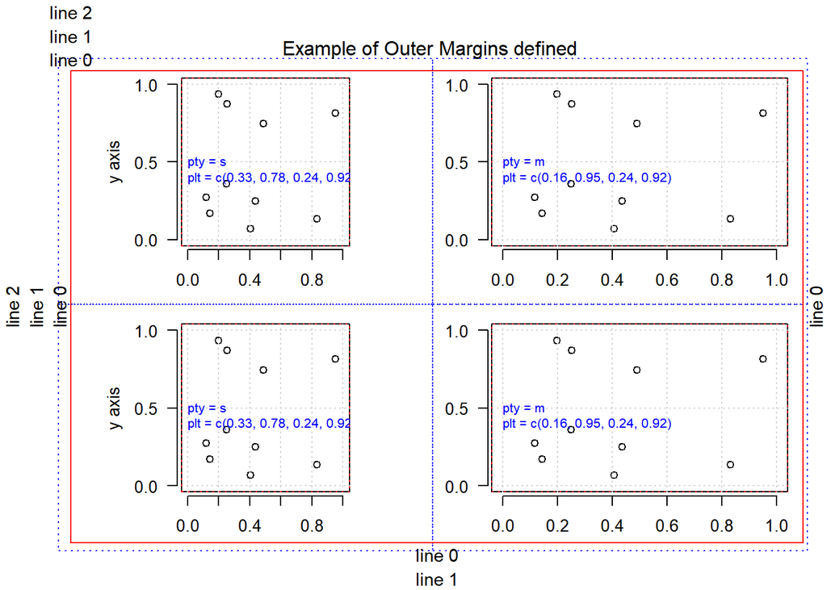

```r
outer_margin <- function() {
    par(las = 0)
    for(k in 0:1){
        mtext(paste0("line ", k), line = k , side = 1, cex = 0.9, outer = TRUE)
    }
    for(k in 0:2){
        mtext(paste0("line ", k), line = k, side = 2, cex = 0.9, outer = TRUE)
    }
    for(k in 0:2){
        mtext(paste0("line ", k), line = k, at = 0, side = 3, cex = 0.9, outer = TRUE)
    }
    for(k in 0:0){
        mtext(paste0("line ", k), line = k, side = 4, cex = 0.9, outer = TRUE)
    }
}

par(op)
par(oma = c(2, 3, 3, 1))
par(mfrow = c(2,2), mar = c(3, 3, 1, 1), mgp = c(3, 1, 0.2)
    , bty = 'o'
    , las = 1
    , lab = c(4, 3, 7))
pty_values <- c("s", "m", "s", "m")
for(k in 0:3){
    set.seed(1023)
    par(pty = pty_values[k + 1])
    plot(runif(10), runif(10)
        , xlim = c(0, 1), ylim = c(0, 1)
        , xlab = "x axis", ylab = "y axis"
        )
    grid()
    box("plot", col = "red", lty = "14")
    box("figure", col = "blue", lty = "14")
    text(0, 0.5, paste("pty =", par("pty")), adj = 0, col = "blue", cex = 0.8)
    text(0, 0.4,
        paste0("plt = c(", paste(round(par("plt"), 2), collapse = ", "), ")"), cex = 0.8, col = "blue", adj = 0)


}
mtext(text = "Example of Outer Margins defined ", line = 0, side = 3, outer = TRUE)
par(mfrow = c(1, 1), new = TRUE)
box("figure", col = "red")
outer_margin()
```

## smo

(Unimplemented) a value which indicates how smooth circles and circular arcs should be.